# Prosper - Exploratory data analysis with R

Variable should_pay_toClose shows repayable amount, but where loan term is based on month difference between loan close and origination date. This calculation may not be correct due to amortized way of processing borrowers payments (each payment with different amount to pay down principal and interest, see https://www.lendingmemo.com/amortization-calculator/), but because dataset does not contain any detailed payment information associoated to listing (dates and amounts), it could provide at least some hints.

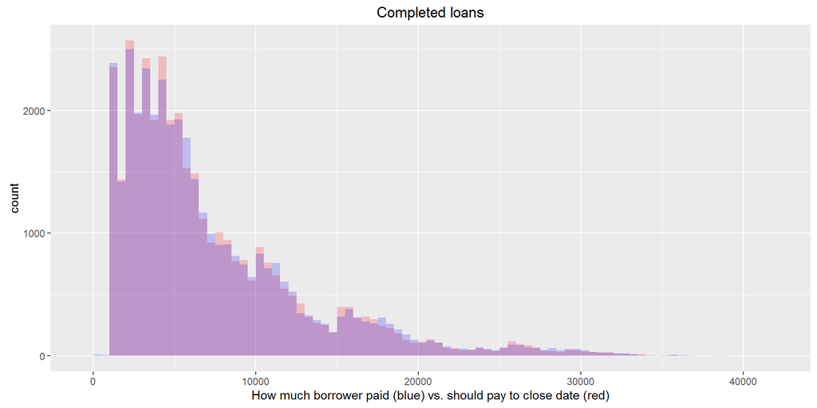

Variable should_pay_toMonth shows what amount the borrower should have paid at current month, or original repayable amount, when its after repayment date.

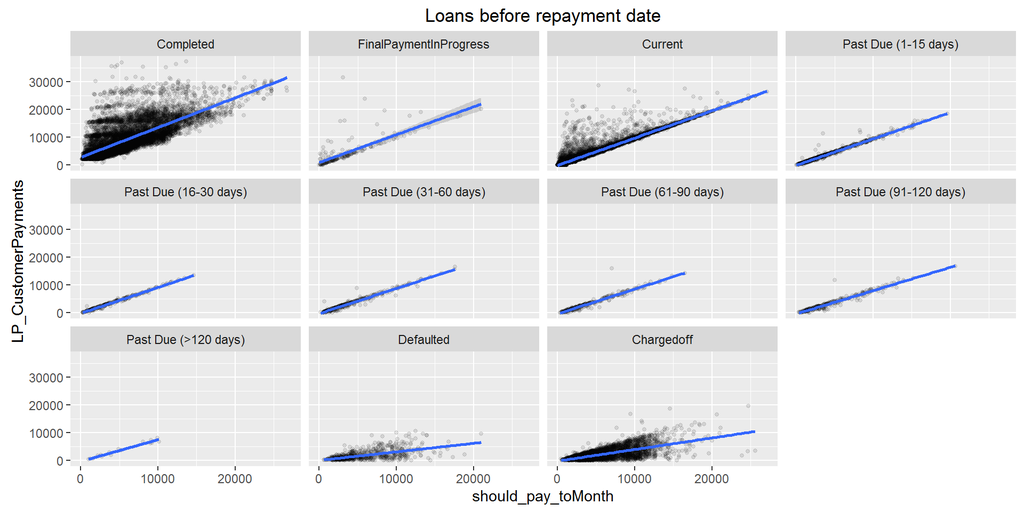

Summary of should_pay_toMonth_diff by loan status on loans before repayment date:

```
## ld[ld$sign_repDate == "before_repDate", "LoanStatus"]: Completed
##    Min. 1st Qu.  Median    Mean 3rd Qu.    Max.
##  -31620   -4434   -1739   -3160    -518    3412
## --------------------------------------------------------
## ld[ld$sign_repDate == "before_repDate", "LoanStatus"]: FinalPaymentInProgress
##     Min.  1st Qu.   Median     Mean  3rd Qu.     Max.
## -28540.0   -106.2    162.6   -851.5    303.0    922.0
## --------------------------------------------------------
## ld[ld$sign_repDate == "before_repDate", "LoanStatus"]: Current
##     Min.  1st Qu.   Median     Mean  3rd Qu.     Max.
## -23410.0    116.2    234.1    210.4    387.3   1769.0
## --------------------------------------------------------
## ld[ld$sign_repDate == "before_repDate", "LoanStatus"]: Past Due (1-15 days)
##    Min. 1st Qu.  Median    Mean 3rd Qu.    Max.
## -7865.0   191.9   345.9   373.3   548.0  2427.0
## --------------------------------------------------------
## ld[ld$sign_repDate == "before_repDate", "LoanStatus"]: Past Due (16-30 days)
##    Min. 1st Qu.  Median    Mean 3rd Qu.    Max.
## -1377.0   307.9   417.8   536.5   745.4  1773.0
## --------------------------------------------------------
## ld[ld$sign_repDate == "before_repDate", "LoanStatus"]: Past Due (31-60 days)
##    Min. 1st Qu.  Median    Mean 3rd Qu.    Max.
## -3877.0   422.2   588.4   746.8  1017.0  3727.0
## --------------------------------------------------------
## ld[ld$sign_repDate == "before_repDate", "LoanStatus"]: Past Due (61-90 days)
##    Min. 1st Qu.  Median    Mean 3rd Qu.    Max.
## -8876.0   528.8   719.1   901.3  1210.0  3628.0
## --------------------------------------------------------
## ld[ld$sign_repDate == "before_repDate", "LoanStatus"]: Past Due (91-120 days)
##    Min. 1st Qu.  Median    Mean 3rd Qu.    Max.
##   -6610     691     938    1216    1641    4032
## --------------------------------------------------------
## ld[ld$sign_repDate == "before_repDate", "LoanStatus"]: Past Due (>120 days)
##    Min. 1st Qu.  Median    Mean 3rd Qu.    Max.
##   430.2   796.1  1340.0  1505.0  1892.0  3493.0
## --------------------------------------------------------
## ld[ld$sign_repDate == "before_repDate", "LoanStatus"]: Defaulted
##    Min. 1st Qu.  Median    Mean 3rd Qu.    Max.
##   -2299    2052    3300    4094    5579   16840
## --------------------------------------------------------
## ld[ld$sign_repDate == "before_repDate", "LoanStatus"]: Chargedoff
##    Min. 1st Qu.  Median    Mean 3rd Qu.    Max.
##   -7163    1761    2888    3569    4684   22180
```

```
## [1] "1   100 %  ---  should_pay_toMonth_diff"
##       Min.    1st Qu.     Median       Mean    3rd Qu.       Max.
## -31620.000      7.855    217.800    -34.060    416.000  22180.000
```

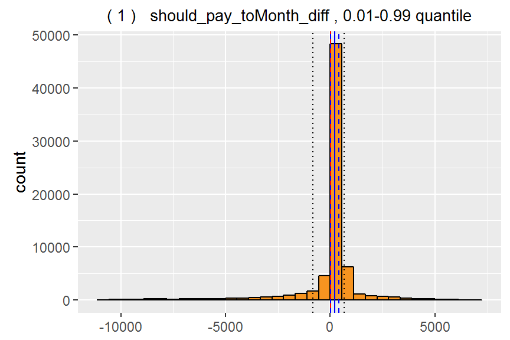

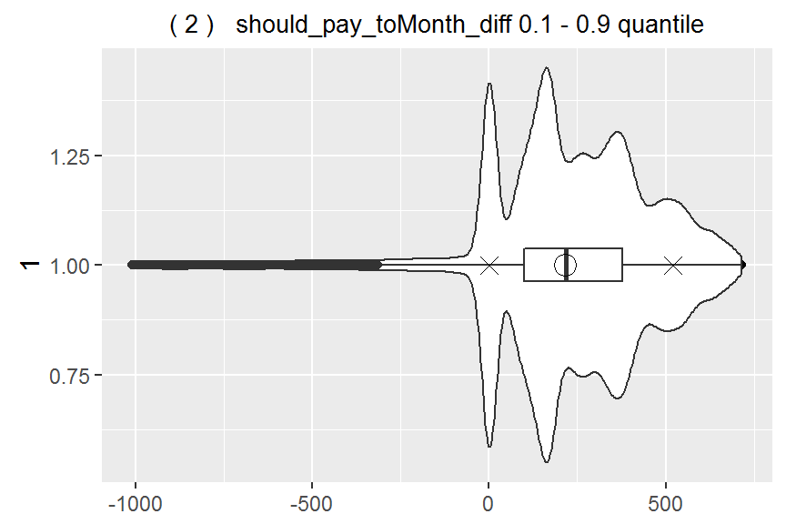

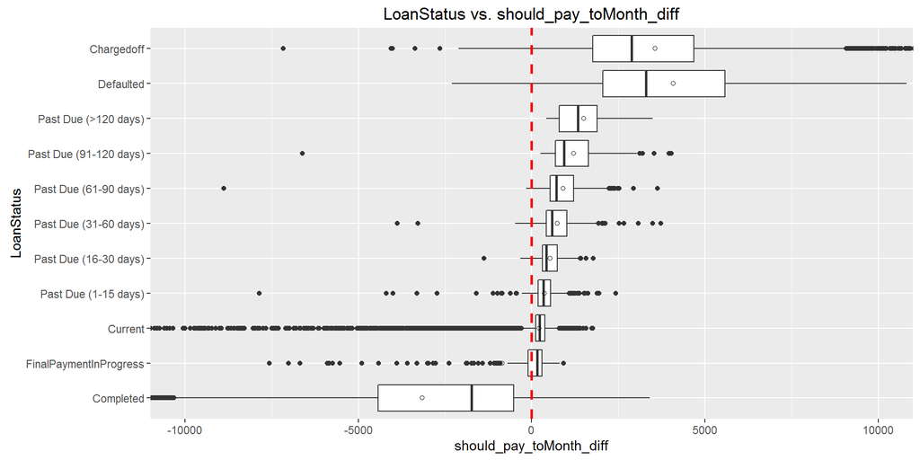

From plots and summary of difference between how much borrower paid and should pay on loans before repayment date in given month after loan origination date, we see how borrower pays accorging to scheduled monthly payments. In completed loans we see already described pattern, that they tend to be repaid earlier for less amount than original and the borrower pays more than scheduled at given month, on the contrary to delinquent loans. I will use variable should_pay_toMonth_diff as target variable.

Other variables, which I will use as targets:

- should_pay_toMonth_diff_relative,
- remain_toMonth_diff,
- remain_toMonth_diff_relative,
- pay_remain_current,
- pay_until_current
- latePayments_ratio

latePayments_ratio is a ratio of total late payments of borrower’s prosper history to total payments billed. It’s valid for borrowers, which had at least 1 loan before.

Now, when I have target variables, for which I was looking for, I can begin analysing their relationships to input variables. Following tables contain all variables, which I created, to better describe loans or borrowers, help and target variables.

#### New variables created for each listing:

| Variable | Description |
| --- | --- |
| YearlyIncome | stated monthly income * 12 |
| closed_after_orig | how much months was loan closed after origination date |
| closed_before_repDate | how much months was loan closed before original repayment date |
| closed_before_repDate_relative | relative from loan original term |
| months_until_repDate | how much months has loan currently until original repayment date |
| months_until_repDate_relative | relative from loan original term |
| sign_repDate | if the loan is after, or before repayment date |
| is_closed | if the loan is closed or not |
| MonthlyLoanPayment_manual | manually calculated monthly payment |
| should_pay | original repayable amount of the loan at original repayment date |
| should_pay_interest | original interest part of repayable amount of the loan at original repayment date |
| should_pay_interest_relative | relative from original repayable amount |
| should_pay_toClose | repayable amount to pay in month when the loan was closed, completed loans |
| should_pay_toClose_interest | interest part of repayable amount to pay in month when the loan was closed, completed loans |
| should_pay_interest_all | how much should borrower pay interest, different calculation for completed and other loans |
| AmountDelinquent_principal_ratio | currently delinquent amount as portion from principal |
| AmountDelinquent_income_ratio | currently delinquent amount as portion from stated monthly income |
| should_pay_toMonth | how much should borrower pay to current month, or to repayment date, when its after |
| should_pay_toMonth_diff | difference between how much borrower should pay at given month and really paid |
| should_pay_toMonth_diff_relative | relative to should_pay_toMonth |
| should_remain_toMonth | amount which should remain to pay at given month |
| remain_toMonth | amount which remains to repay at given month |
| remain_toMonth_diff | difference between how much borrower should have remaining amount to repay and really has |
| remain_toMonth_diff_relative | relative to should_remain_toMonth |
| pay_remain_current | amount left to repay / scheduled amount to repay at given month |
| pay_until_current | amount paid / scheduled amount which should be paid at given month |

#### New variables created when grouping by borrower:

| Variables | - |
| --- | --- |
| LessOneMonthLatePayments_ratio | TotalCustomerPayments |
| PlusOneMonthLatePaymetns_ratio | TotalInterestandFees |
| OnTimePayments_ratio | LastLoanStatus |
| latePayments_ratio | TotalInvestors |
| TotalProsperLoans | last category of categorical variables and all categories coancenated |
| TotalProsperPaymentsBilled | average, maximum interval in months between loan origination dates |
| OntimeProsperPayments | average, maximum interval in months between loan close date and next loan origination date |
| ProsperPaymentsLessThanOneMonthLate | average, minimum, maximum of selected continuous variables |
| ProsperPaymentsOneMonthPlusLate | average, minimum, maximum growth of selected continous variables |
| ProsperPrincipalBorrowed | - |

#### Target vs. input variables

I think, that for search for patterns in input variables might be reasonable to use only loans in completed, defaulted and charged off status because differences between these 2 opposite groups should be more ‘visible’, and loans before repayment date because of setup calculations. First, lets briefly examine distribution of target variables.

```
## [1] "1   16.67 %  ---  should_pay_toMonth_diff"
##     Min.  1st Qu.   Median     Mean  3rd Qu.     Max.
## -31620.0  -2878.0   -618.8  -1023.0   1683.0  22180.0
```

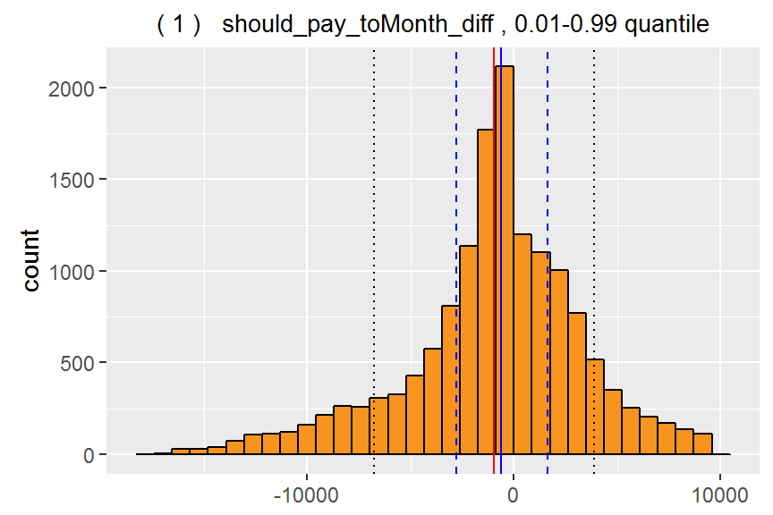

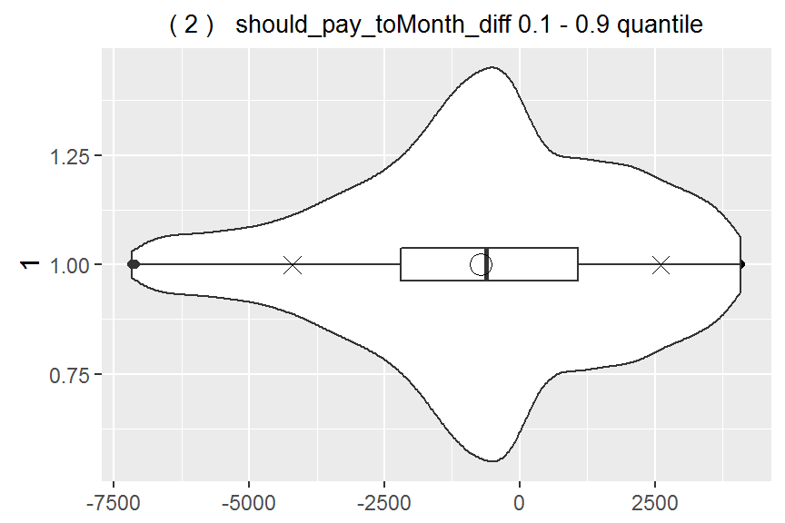

```
## [1] "2   33.33 %  ---  should_pay_toMonth_diff_relative"
##     Min.  1st Qu.   Median     Mean  3rd Qu.     Max.
## -19.7200  -0.6814  -0.1257  -0.4459   0.4305   1.0030
```

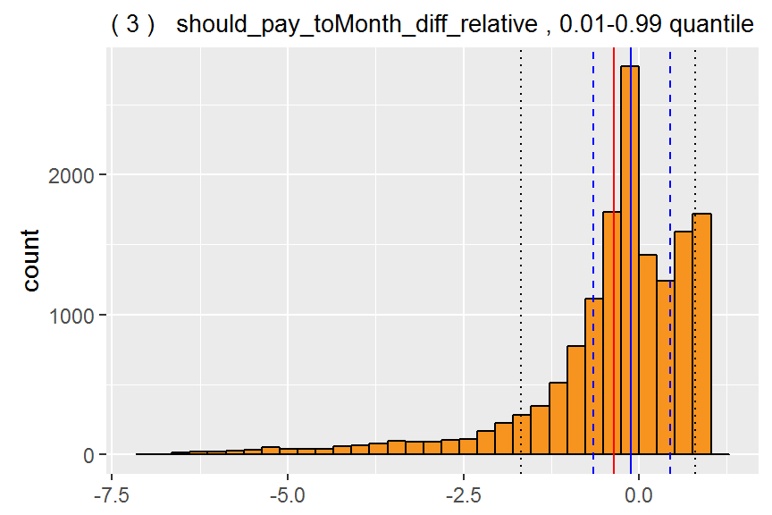

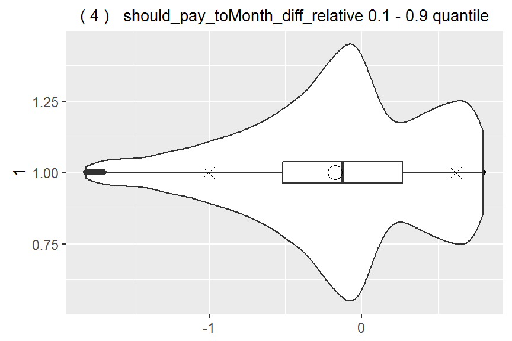

```
## [1] "3   50 %  ---  remain_toMonth_diff"
##     Min.  1st Qu.   Median     Mean  3rd Qu.     Max.
## -22180.0  -1683.0    618.8   1023.0   2878.0  31620.0
```

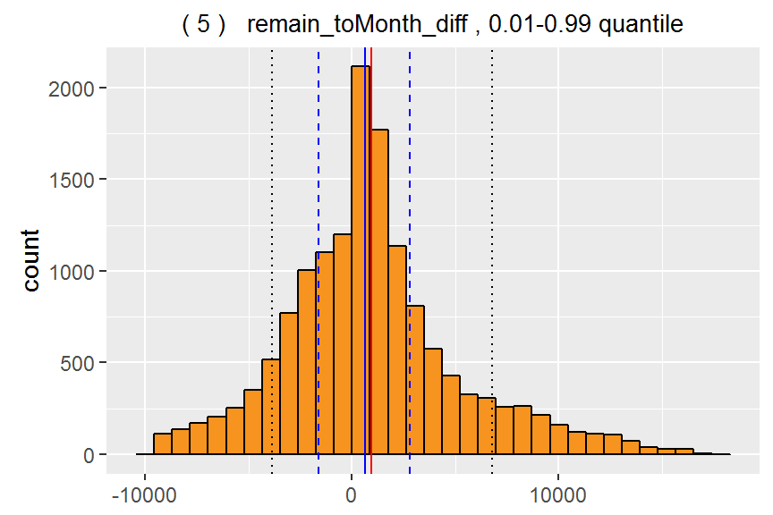

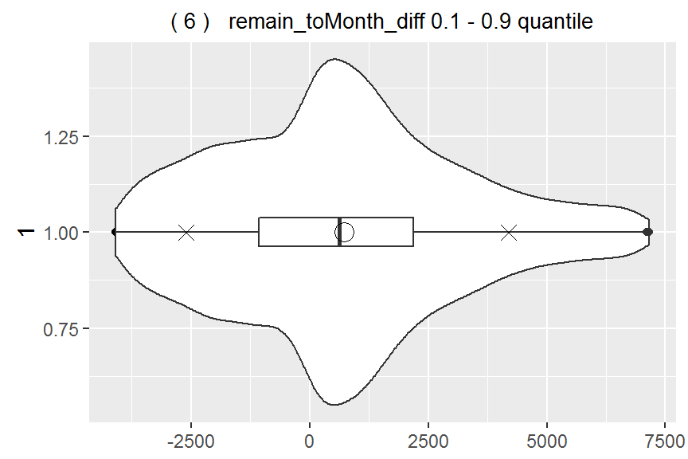

```
## [1] "4   66.67 %  ---  remain_toMonth_diff_relative"
##     Min.  1st Qu.   Median     Mean  3rd Qu.     Max.
## -35.0000  -0.5714   0.4163  -0.5353   0.6838   1.7790
```

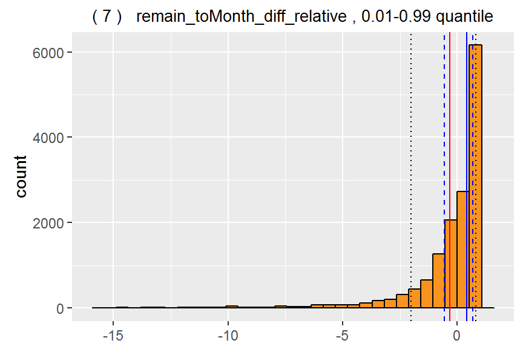

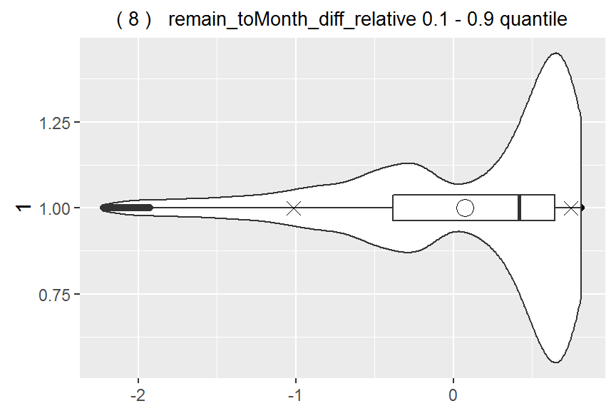

```
## [1] "5   83.33 %  ---  pay_until_current"
##    Min. 1st Qu.  Median    Mean 3rd Qu.    Max.
##    -372       1       1     Inf       2     Inf
```

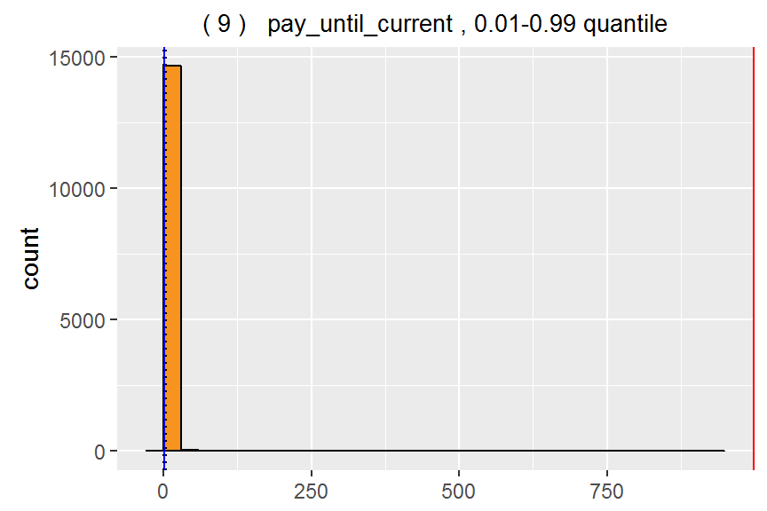

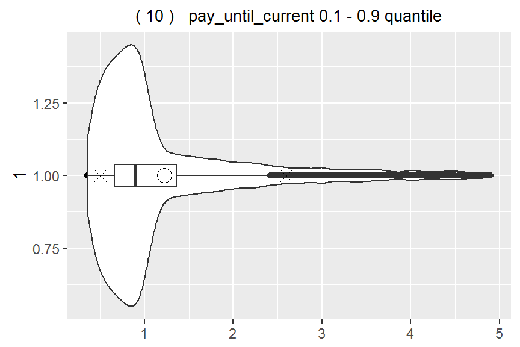

```
## [1] "6   100 %  ---  pay_remain_current"
##      Min.   1st Qu.    Median      Mean   3rd Qu.      Max.
## -384.3000    0.6338    1.7060    2.4980    3.1500  765.9000
```

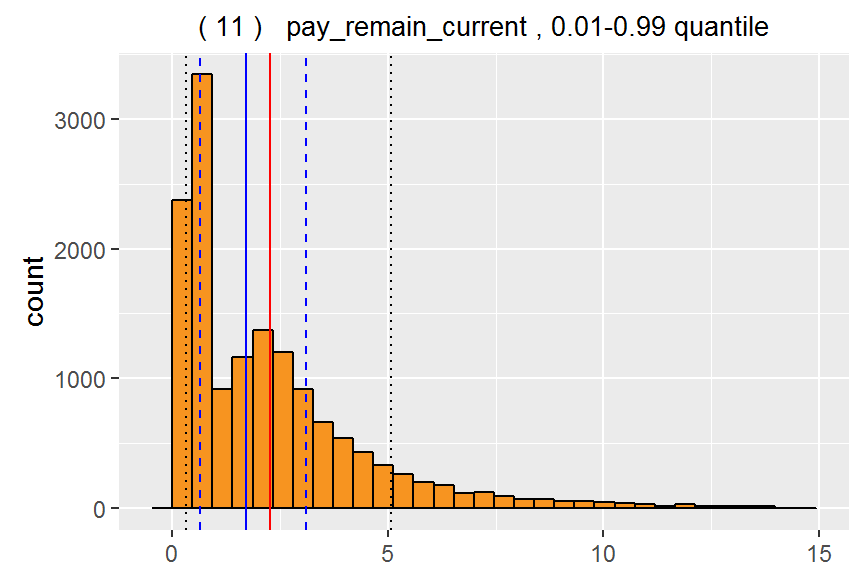

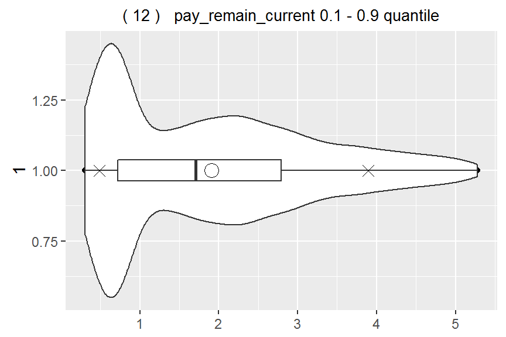

Variables should_pay_toMonth_diff and remain_toMonth_diff have very close to normal distribution. Variable should_pay_toMonth_diff relative and remain_toMonth_diff_relative are both left skewed. Variable pay_until_current is right skewed with most of the values between 0 and 2. Important number in pay_until_current and pay_remain_current is 1, which is the turning point between paying more/less than scheduled. For both variables may be some sort of transformation needed. Variable latePayments_ratio has only 1434 values bigger than 0, which is in my opinion very few to show any meaningful patterns in input variables, so I excluded it from analysis.

### Found relationships and final plots

Since this dataset contains many input variables, I will include only these, where I found signs of possible relationship to target variables and few selected ones, which contain interesting information. The way how I did examine relationships between targets and inputs include:

- brief check of relationship on 0.01 - 0.99 quantile of both variables
- analyzing the relationship in steps towards 0.25 - 0.75 quantile of target variable, 0.01 - 0.99 quantile of input variable
- analyzing the relationship on 0.1 - 0.9 or 0.2 - 0.8 quantile of both variables
- brief check of most ‘dense’ part according to density heatmap, manually creating subsets
- binning of continuous input variables according to quantiles (equally sized groups) or values

Variables, which show signs of relationships with targets include:

| Variables | - |
| --- | --- |
| IncomeRange | IncomeVerifiable |
| PublicRecordsLast10Years | InquiriesLast6Months |
| TotalProsperLoans.x | ProsperRating_numeric |
| ProsperRating_alpha | ProsperScore |
| ListingCategory_numeric | EmploymentStatus |

Following plots show combination of input and target variables, where is the relationship most visible, but similar relationship as showed we can observe with all target variables. Red line indicates the turning point, box color indicates if category median is in part where borrower pays better (green) / worse (red) than scheduled, black number near each box indicates percentage of loans in given category from all loans, red number indicates percentage of loans which are repaid worse than scheduled in given category from all loans which are repaid worse than scheduled. Underlying violin plots visualize estimation of probability density function of target variable. Final dataset, which was analyzed contains 15012 loans.

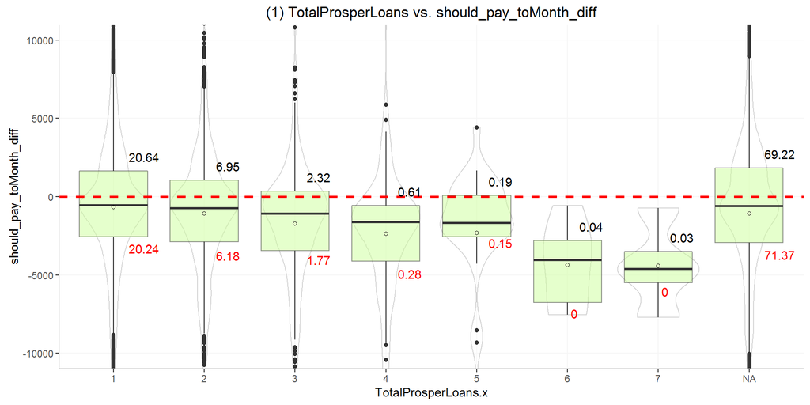

```
##
##  Spearman's rank correlation rho
##
## data:  TotalProsperLoans and should_pay_toMonth_diff
## S = 5.7548e+11, p-value = 0.01149
## alternative hypothesis: true rho is not equal to 0
## sample estimates:
##        rho
## -0.0206284
```

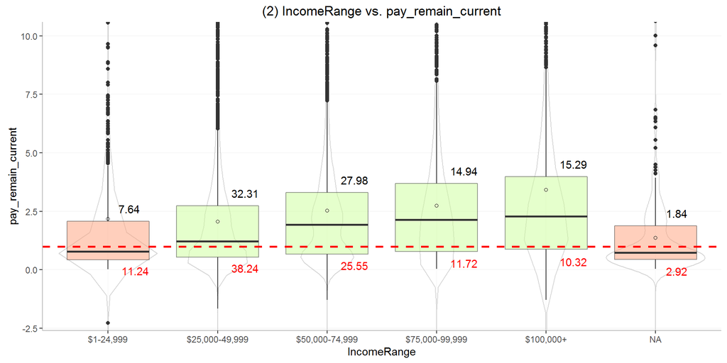

```
##
##  Spearman's rank correlation rho
##
## data:  IncomeRange and pay_remain_current
## S = 4.4458e+11, p-value < 2.2e-16
## alternative hypothesis: true rho is not equal to 0
## sample estimates:
##       rho
## 0.2115299
```

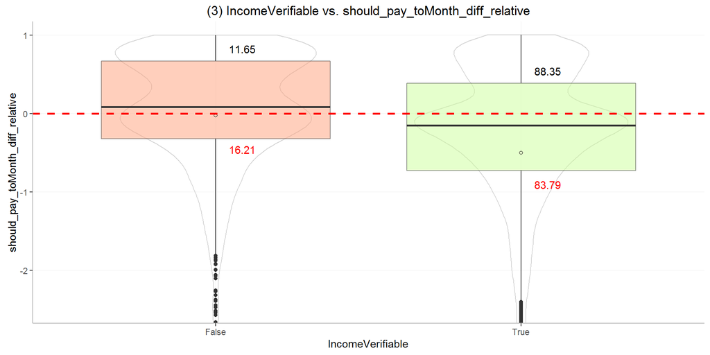

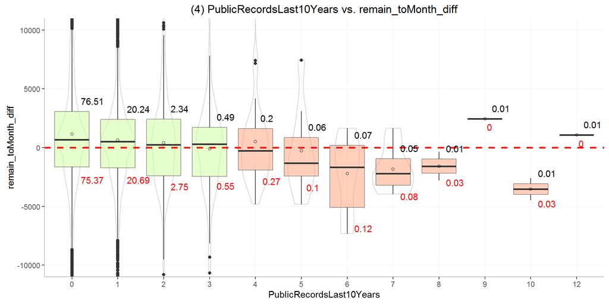

```
##
##  Spearman's rank correlation rho
##
## data:  PublicRecordsLast10Years and remain_toMonth_diff
## S = 5.8786e+11, p-value = 1.801e-07
## alternative hypothesis: true rho is not equal to 0
## sample estimates:
##         rho
## -0.04257813
```

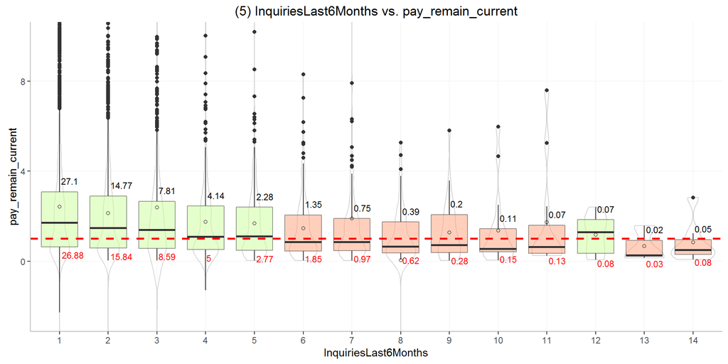

```
##
##  Spearman's rank correlation rho
##
## data:  InquiriesLast6Months and pay_remain_current
## S = 6.4247e+11, p-value < 2.2e-16
## alternative hypothesis: true rho is not equal to 0
## sample estimates:
##        rho
## -0.1394325
```

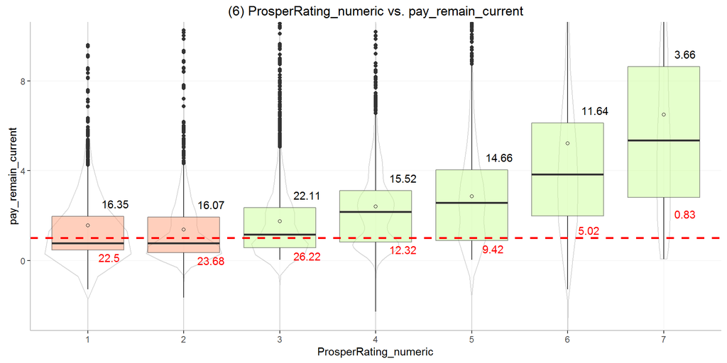

```
##
##  Spearman's rank correlation rho
##
## data:  ProsperRating_numeric and pay_remain_current
## S = 3.1487e+11, p-value < 2.2e-16
## alternative hypothesis: true rho is not equal to 0
## sample estimates:
##       rho
## 0.4415677
```

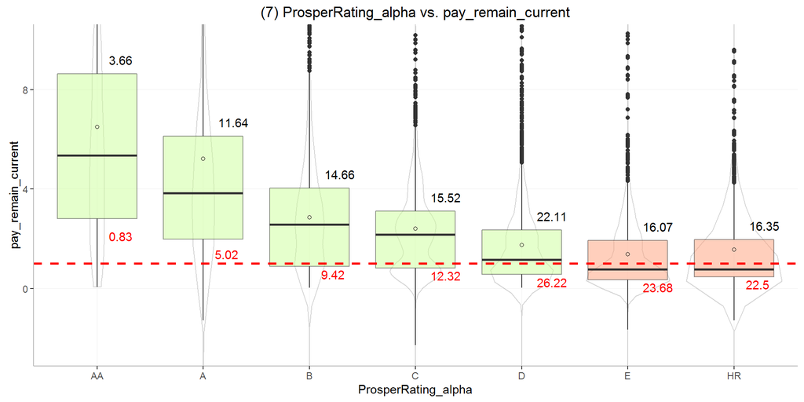

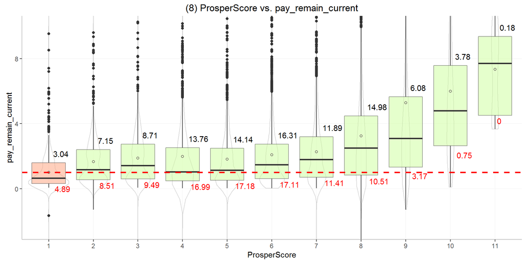

```
##
##  Spearman's rank correlation rho
##
## data:  ProsperScore and pay_remain_current
## S = 3.9784e+11, p-value < 2.2e-16
## alternative hypothesis: true rho is not equal to 0
## sample estimates:
##       rho
## 0.2944183
```

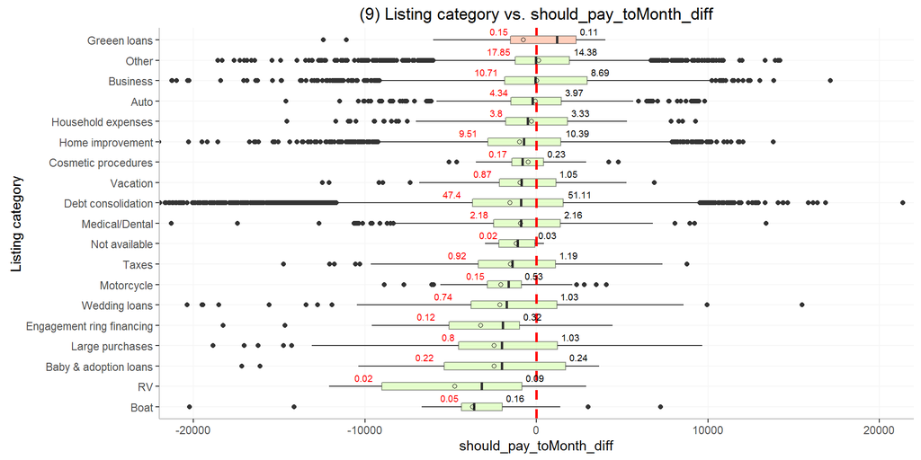

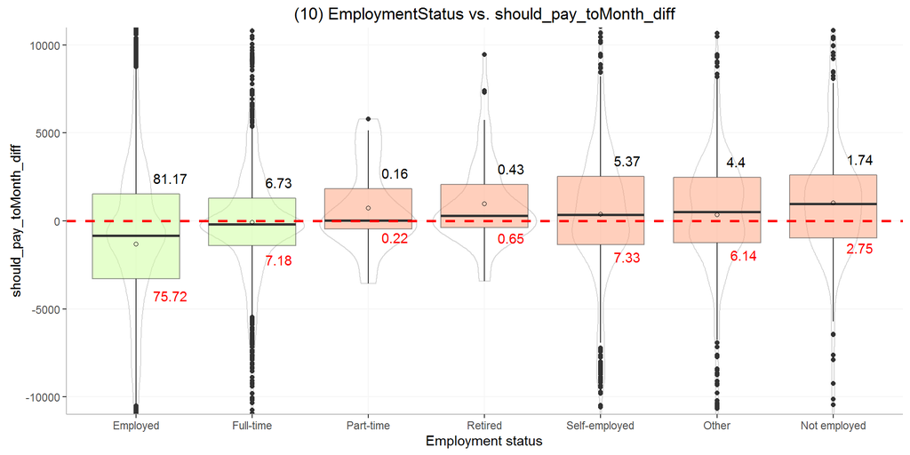

### Plots summary

Some of showed plots confrmed my assumptions about certain categories and related values of target variables. For example total number of borrower prosper loans, where we see trend, that with higher number of previously taken loans, the borrowers ability to repay them increases. NA values are assiociated with listings of 1st time borrowers, which is also the largest group. Most of loans, which are repaid worse than scheduled are from this category.

Except summary statistics of target variable visualized as boxplot (mean, median, 1st and 3rd quartile), important thing to look at, which explains them in more detail, is approximate shape of distribution in form of underlying violin plot. From plots where we can identify bimodal distributions, we see how density around each mode changes according to input variable category in favour of 1st or 2nd mode. This can be explained due to change of relative number of occurencies wihtin each category between 2 subsets of our interests (completed vs. defaulted and charged off loans).

My expectations where confirmed for IncomeRage, IncomeVerifiable variable and for borrowers employment status as well, that employed people will pay the best, but the meaning of categories is a bit unclear (difference between ‘Employed’ and ‘Full-time’ category, clarification of ‘Other’ and ‘Not employed’ category - what other source of income the borrower has?). NA values in IncomeRange are ‘not displayed’ and ‘not employed’ categories, which I changed at the beginning. ‘Employed’ is category with biggest share on loans, which are repaid worse than scheduled.

What I did not expected is relationship to number of inquiries in last 6 months and borrowers public records for 10 years. My expectations were wrong for listing category, where I expected, that borrowers with debt consolidation loan reason pay the worst. These loans make more than half of all loans and 47.4 percent of loans which are repaid worse than scheduled.

Prosper scoring and rating variables are in relation with target variables as well. Here, except 2 modes we can see, that for better rated loans is the variance bigger than for lower rated ones, which are more concentrated around the turning point.

## Reflection

Altough performed analysis revealed noticable relationships with variables, which describe borrowers ability to repay a loan, my goal on the beginning of the analysis was to find continuous variable with much more evident relationship as found categorical ones and create regression model.

Process from beginning with dataset consistency validation to identify variables with relationships to targets was a bit uncertain, because I did not know what should be the calculation of variable, which gives me answer to question asked. Ideas of target variables calculations came during dataset validation when having more information about its content.

Neccessary to perform analysis of such a number of variables, which were originally included plus created ones, required to create functions saving time and which quickly reveal as much possible in terms of variables main characteristics and their relations.

Regarding variables, which were originally at disposal, I think, that detailed information about borrowers payments, their dates and amounts should be available as well. Interesting may be some variables describing process of listing evaluation too, and more detailed borrowers characteristics (married, number of children, number of people living in the household, age, education earned, etc.).

Ways, how this analysis could be extended may be focused on:

- exploring loans wich have after repayment date
- performing statistical tests to know if differences between found variables categories are significant
- split analysis to old business model/new business model (july 2009), or when some another important event occured

#### References

http://www.cookbook-r.com/Manipulating_data/Recoding_data/

http://www.rapidtables.com/web/color/RGB_Color.htm

http://stackoverflow.com/questions/11838278/plot-with-conditional-colors-based-on-values-in-r

http://www.introductoryr.co.uk/Reproducibility/Chap_6_Maths.html

http://stackoverflow.com/questions/22238278/fine-tuning-ggplot2s-geom-boxplot

http://stackoverflow.com/questions/15660829/how-to-add-a-number-of-observations-per-group-and-use-group-mean-in-ggplot2-boxp

http://kbroman.org/knitr_knutshell/pages/Rmarkdown.html

https://google.github.io/styleguide/Rguide.xml

http://www.rcreditscoring.com/binning-continuous-variables-in-r-the-basics/

http://stackoverflow.com/questions/21208801/group-by-multiple-columns-in-dplyr-using-string-vector-input

https://groups.google.com/forum/#!topic/manipulatr/Augi_tPUTY8

http://stackoverflow.com/questions/23528862/summarize-with-conditions-in-dplyr

http://stackoverflow.com/questions/29904974/conditionally-count-in-dplyr

http://osdir.com/ml/ggplot2/2013-07/msg00068.html

http://stackoverflow.com/questions/28752805/use-dplyr-to-concatenate-a-column

http://princeofslides.blogspot.sk/2011/02/fixing-up-smoothscatter-heat-maps.html

http://venus.ifca.unican.es/Rintro/graphs.html

https://chemicalstatistician.wordpress.com/2013/06/09/exploratory-data-analysis-kernel-density-estimation-in-r-on-ozone-pollution-data-in-new-york-and-ozonopolis/